# Silent Failures in Automation. Pilot dataset Calculating Measures and Descriptive Plotting

Callum Mole

## Introduction

This document serves as a report for a first run of the pre-registered experiment https://osf.io/s6vam/. The experiment examines silent failures in a highly controlled setting. Each trial starts with automated steering. In some trials a bias is introduced that causes the vehicle to veer off the road either suddenly (within 1.5 s) or gradually (~ 4 s). Participants are required to keep within the road edges and intervene if they feel that it is necessary. They complete the task without distraction or with a easy or difficult distraction. There are also two bend radii used: sharp (40 m) or gradual (80 m).

### Technical Errors

This experiment stands as a lesson for the need to conduct a full technical pilot - running a participant through the entire experiment then putting that data through the entire analysis workflow. Due to time pressures we often do *some* piloting to ostensibly check data saving, condition indexing etc. But we do not very often take the time to process the data through analysis scripts. In this case the data looked like it was saving correctly when piloting. But there were two key errors. First, the distraction performance files were overwritten when the driver was also steering (we still have the baseline - no steering - distraction performance files). Secondly, the “unique” filename for saving individual trials did not include the yawrate offsets in the title. So, in effect these trials were overwritten and only the last six (randomised) trials were saved for each radii, irrespective of yawrates offsets.

This means that we only have a small amount of data to work with, and the amount of trials performed (or, to be more precise, saved) for each condition is random between conditions. Fig 1 shows how many trials we have. The expected trialcount for each condition is 180 trials in the dataset.

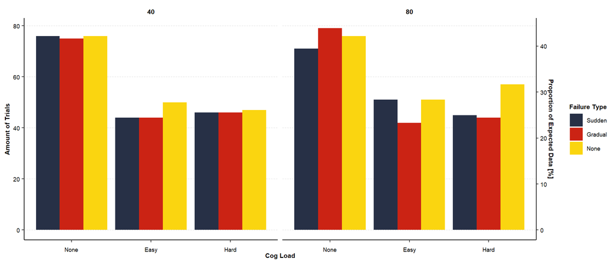

Fig 1. Amount of trials in each condition

Fig 1 shows that for the distraction conditions we only have 20-30 % of the expected data. For driving without distraction we have slightly more because there are two blocks. For the trials we do have we have complete steering and gaze data, so at the very least the reduced data set will be useful at tweaking the design for an improved re-run, and for developing the modelling architecture.

### Cognitive Load difficulty.

We only have the cognitive performance for baseline (without steering). Here we plot three indices of performance: *Percentage Correct* (PC, True positives + True negatives / total letters heard); *Reaction Time* (RT, reaction time for True positives); *Proportional Absolute Count Error* (average distance from the true count, expressed as a proportion of the total amount of targets heard).

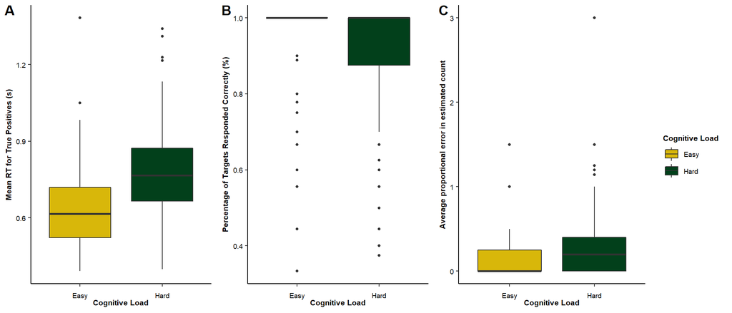

Fig 2 shows that people respond differently to each Cognitive Load condition. Participants react slower to heard target letters if they are listening for three targets as compared to one target (Fig 2A). Participants rarely make mistakes (i.e. responding to a distractor letter or not responding to a target letter) in the Easy Cognitive Load condition, they make more mistakes in the hard Cognitive Load condition (Fig 2B).

The interpretation of the last measure, the count error (Fig 2C), is more nuanced. Assessing accuracy of estimated counts is tricky because the amount of occurences of each target in the *Hard* condition is generally a third of the count of the target in the *Easy* condition. It is worth noting that the total error (cumulative across multiple targets) is pretty identical across both conditions. How you use then use this total count error to take into account people are responding to more targets *Hard* than *Easy* is the debateable bit. For example, estimating five instead of six has the same total error as estimating zero, two, three, for target counts of one, two and three. Yet one could argue that the two responses are qualitatively different because in the second case the participant has entirely missed a target but got the other two spot on. To reflect this I’ve chosen to express this measure as a proportional of the total amount of targets heard (Fig 2C). In any case, people are only marginally less accurate on this measure in the *Hard* cognitive load than for *Easy*. It seems that the more precise measures of RT and PC are better indicators of differences in performance.

Therefore, a quick eyeball of the baseline cognitive task performance suggests that people reacted slower and experienced greater difficulty in deciding the appropriate response when there were three targets as compared to when there was only one.

Let’s see how this gets reflected in steering measures.

### Steering.

The pre-registration specifies two steering related hypotheses:

- **H1**: Participants will react slower to silent failures as cognitive load increases (i.e. more time will elapsed from the yaw rate offset to the driver disengaging the automation).
- **H2**: Participants will react with less aggression as cognitive load increases, bringing the vehicle back to the centre more slowly (i.e. they will be smoother and make less corrections).

#### H1: Speed of take-over

The pre-registration states that we will calculate two measures:

- RT from yawrate-drift onset to disengagement of the system via a button press (can be negative if they take over before the yaw-rate bias is introduced). I will refer to this measure as RT<sub>takeover</sub>.
- RT from yawrate-drift onset to first steering movement (RT<sub>steer</sub>).

For the purposes of a quick look at the pilot dataset I will only calculate RT<sub>takeover</sub> for now.

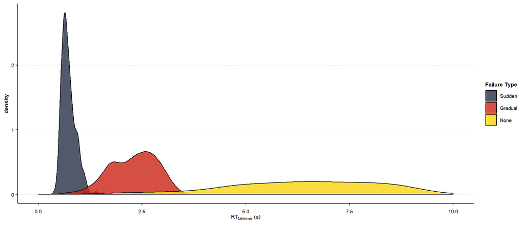

Fig 3. RT takeover across failure types

Fig 3 shows massive differences in how quickly drivers disengage the automation after the yawrate onset. In the *None* condition drivers disengaged the system in 43.1962025 % of trials. Since drivers react at such different speeds across the three failure types the failure type conditions will be look at in turn.

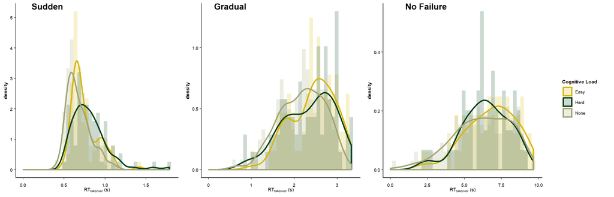

Fig 4. RT takeover across cognitive loads

Fig 4 shows cognitive load differences in RT<sub>takeover</sub> within failure type. For Sudden failures (leftmost in Fig 4) there are clear difference between None, Easy, and Hard. People switch to manual mode quickest when not performing a distractor task; they switch slowest when the distractor task is more difficult. This difference is less pronounced for Gradual failures (middle) and No failures (right). Part of the difficulty in interpreting the distributions is due to the depleted dataset. In the Sudden condition all the data falls within fairly narrow regions (0-2s) so smooth density estimates are observed despite the relatively low numbers of trials. In the Gradual Failure and No Failure conditions the data is spread out over a wider range so there begin to be ‘gaps’ in the distribution (effectively, unsampled space). Therefore the density estimates are bumpier and it is more difficult to see clear differences. The histograms in the background how the gaps and spikes correspond to bumps in the density estimate. Nevertheless, in the Gradual condition I am tempted to predict that with more data we would see clear differences begin to emerge between the no load condition and when the driver is cognitively loaded.

**H1** : of course this needs inferential statistics to support my eyeballing, but I will tentatively suggest that reaction time to silent failures does indeed increase as cognitive load increases, though this effect depends on the severity of the failure.

### Gaze

### Steering and Gaze

### with/without automation.

### plots of steering trajectories.

### plots of gaze.